# Week 2 Lab: Compliance – Descriptive Statistics and exceedance Probabilities

**Consistent deviations in the tails can suggest that the distribution used (log-normal in this case) might not characterize the data best.**

The **black line** represents the theoretical cumulative distribution function (CDF) of a log-normal distribution fitted to the data. Ideally, if the data perfectly follow the log-normal distribution, the points should lie close to this line.

**Outliers:** Any significant deviations from the line, especially towards the upper end of the plot, may indicate the presence of outliers or that the data has a heavy tail.

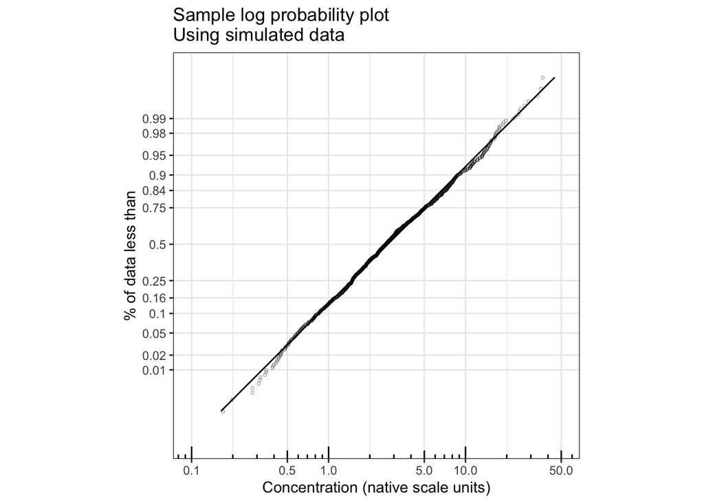

```r
#-----log probability plot----

# Shows percentiles of the cumulative normal on the y axis;
# coord_fixed assumes both axes are the same scaling (i.e. the aspect ratio for x, qx is the same);
# annotation_logticks puts in minor ticks in right scaling
# minor_breaks addresses the unlabeled grid lines
p <- ggplot(data = pplot_data) +
    geom_point(aes(x,qx), shape = "o", alpha = 0.4) +
    geom_line(aes(qx,qx)) +
    annotation_logticks(sides="b") +
    # axes on the log base 10 scale;
    scale_x_log10(breaks=c(0.1,0.5,1,5,10,50),
                  limits=c(0.1,50),
                  minor_breaks=c(0.2,1,2,20) ) +
    scale_y_log10(breaks=exp_quants,
                  labels=probs,
                  limits=c(0.1,50),
                  minor_breaks=NULL) +
    coord_fixed() +
    labs(title="Sample log probability plot\nUsing simulated data",
         x = "Concentration (native scale units)",
         y= "% of data less than") +
    theme_bw()
p
```

# Practice Session

1. Using the ‘DEMSCombinedPersonal’ R dataset, keep only measurements from jobs 110, 240, 410 and 600 among underground workers. (We have selected these particular jobs for simplicity, but feel free to explore additional jobs or other categories of the data if you want to.) In order to avoid potential confusion later, for this practice session we suggest you also drop any observations that are missing `ecdata`.
2. Describe REC (varname: `ecdata`)
3. Determine whether REC in this subset is lognormally distributed. Explore using histograms, qqplots, and statistical tests.
4. Calculate the GM, GSD, and AM (using both method of moments and maximum likelihood estimates for the AM) for each group.
5. For a selected group (i.e. a single job, or for all four if you want): Assume data are lognormal (LN) and an OEL of 200 $\mu g/m^3$ has been determined for REC.
   1. Calculate the empiric and parametric exceedance probabilities along with the 95<sup>th</sup> percentile and 70% confidence limits.
   2. Take a random sample of 50%, 25%, n=9 and n=5 samples and recalculate the GM, GSD, 95<sup>th</sup> percentile $\pm$ 70% confidence limits.

# Homework Exercises

1. Consider the primary exposure measures of interest to the study, including REC, NO_2 and organic carbon. Choose either the full dataset or a reduced subset, such as the four selected underground jobs. (Justify your choice as part of your lab write-up.)
   1. Describe the distribution, out of range and/or missing values for these exposure measures.
   2. Determine the adequacy of the LN distribution for representing these using  
      distribution plots and/or statistical tests.
2. Explore potential stratification variables (determinants such as facility, job, location).
   1. Do the stratified data improve the distributional characteristics? Does it matter whether you restrict your attention to smaller subgroups of the data, e.g., underground only, specific facilities, specific jobs, or a combination of these?
3. Calculate the GM, median, AM (method of moments) and AM (maximum likelihood) for REC.
   1. How do these quantities compare to each other?
   2. Can you determine any characteristics of the data which help explain the differences between these alternative measures of central tendency?
   3. For at least one stratum that has data that aren’t too far off from a lognormal distribution, plot the log probability plot. Read off the GM and GSD from the log probability plot and compare these to values you estimate directly from the data.
4. Assuming an OEL for REC of 200 $\mu g/m^3$, calculate the exceedance probability for each mine (and/or job) using both empiric and parametric approaches. In addition, calculate the 95<sup>th</sup> percentile of the distribution, and provide 70% confidence limits on these percentiles.
   1. What are the differences between the empiric and parametric methods of calculation?
5. Take random samples of the data (e.g., 50%, 10%, n=9, n=5) and recalculate the various summary statistics.
   1. How does the reduced sample size affect the estimates? Explain.

# Appendix 1: Older Base R versions for reference

## A1.1 Q-Q plot

For a q-q plot to determine whether the data are normally distributed, use `qqnorm()` and you can overlay `qqline()`. There is code in the `.Rmd` file if you wish to use it.

```r
#-----clear workspace----

# Clear workspace of all objects and unload all extra (non-base) packages
rm(list = ls(all = TRUE))
if (!is.null(sessionInfo()$otherPkgs)) {
    res <- suppressWarnings(lapply(
        paste('package:', names(sessionInfo()$otherPkgs), sep = ""),
        detach,
        character.only = TRUE,
        unload = TRUE,
        force = TRUE
    ))
}

#-----load packages----

# To address a dependency issue, one package (`limma`) must be installed through
# another package (`BiocManager`)
if (!requireNamespace("BiocManager", quietly = TRUE))
    install.packages("BiocManager")

BiocManager::install("limma")

# For the remaining packages, load pacman, installing as needed
my_repo <- 'http://cran.r-project.org'
if (!require("pacman")) {install.packages("pacman", repos = my_repo)}

# Load the other packages, installing as needed.  Some reasons for packages:
# knitr:  kable
# kableExtra: kable_styling()
# dplyr: data wrangling functions.
# tidyr: drop_na
# ggplot: visualizations
# Hmisc:  describe
# EnvStats: geoMean, geoSD, probability plotting functions
# MKmisc:  quantileCI
pacman::p_load(dplyr, tidyr, knitr, kableExtra, purrr, ggplot2, Hmisc, EnvStats, MKmisc)

knitr::opts_chunk$set(width = 10)

# download_and_read_file() function etc.
source("global_functions.R")

#-----read data----

# create data directory if it does not exist
dir.create(file.path("Datasets"),
           showWarnings = FALSE,
           recursive = TRUE)

# read data; download if necessary
DEMS <- download_and_read_file(data_url = "https://faculty.washington.edu/sheppard/envh556/Datasets/DEMSCombinedPersonal.rds",
                                 output_file_path = file.path("Datasets", "DEMSCombinedPersonal.rds"))

#-----data description 1----------
class(DEMS)

# We expect this to have 1275 rows and 17 columns
dim(DEMS)

# This list should correspond to the list in the data summary document:
names(DEMS)

# # first 6 rows and ALL variables (columns):
head(DEMS)

# a basic summary of each variable
## Question: compare the ecdata mean and median. What does this tell you about the potential distribution of ecdata in terms of normality?
summary(DEMS)

# a different basic summary of each variable from `Hmisc`
describe(DEMS)

#-----filter data----

# filter dataset to keep underground only; 4 jobs codes: 240,110,410,600; and
# non-missing ecdata.
DEMSu <- filter(DEMS,
                u_s == "u",
                job %in% c(240, 110, 410, 600),
                !is.na(ecdata))

#-----transform vars----

# The natural log and log base 10 transformations of ecdata will be added to the
# DEMSu tibble:
DEMSu <- mutate(DEMSu,
                lnrec = log(ecdata),
                log10rec = log10(ecdata) )

# check the new data columns
DEMSu %>%
  select(ecdata, lnrec, log10rec) %>%
  head()

#-----table with dplyr----

# create summary
# note: "summarize()" will call a different function from the Hmisc package
DEMSsummary <- DEMSu %>%
    group_by(job,facilityid) %>%
    summarise(N = n(),
              AM = mean(ecdata),
              # adjusted MLE approach for estimating AM using the log mean and log SD
              AM_mle = (exp(mean(lnrec)+0.5*((N-1)/N)*(sd(lnrec)^2))),
              GM = geoMean(ecdata),
              Median = median(ecdata),
              ASD = sd(ecdata),
              GSD = geoSD(ecdata),
              .groups = "drop") %>%
    mutate_if(is.double, round, digits = 2) %>%
    arrange(job, facilityid, desc(AM))

# print summary using kable
## compare the different estimates of central tendency
## question: why do samples with N=1 have AM_mle missing? - you can't take the SD of only one value
kable(DEMSsummary,
      caption = "Distribution of EC by job and facility",
      digits=1) %>%
  kable_styling()


#-----hist in tidyverse----
# plots on the native scale - data are right skewed
ggplot(data = DEMSu, aes(ecdata)) +
    geom_histogram(colour = "black",
                   fill = "white")


# log REC
p <- ggplot(data = DEMSu, aes(lnrec)) +
    geom_histogram(aes(y = ..density..),
                   colour = "black",
                   fill = "white",
                   binwidth = 0.5
                   )
p

# create dataframe to overlay a normal density curve:
norm_df <- with(DEMSu %>% drop_na(lnrec),
           tibble(x = seq(min(lnrec), max(lnrec), length.out = length(lnrec)),
                  # calculate the density of a normal distribution for a given set of values
                  y = dnorm(x, mean(lnrec), sd(lnrec)) )
           )

# histogram + density + overlaid normal - these look similar
p +
  geom_density(alpha = .2, linetype=2) +
  geom_line(data = norm_df, aes(x = x, y = y), color = "red")  +
  labs(title = paste("Density Plot of ln(REC)\n","In 4 Underground Jobs"),
       caption = paste("With overlaid normal distribution (red line) with the same mean and SD"),
       x = "ln(REC) (ln(ug/m^3)") +
  scale_y_continuous(expand = expansion(mult = c(0, .1))) +
  theme_classic() +
  # left justify the caption
  theme(plot.caption = element_text(hjust = 0))

#-----qqplot in tidyverse----

# create the base plot, overlay the points and line, and add title
## using log REC
ggplot(DEMSu, aes(sample = lnrec)) +
  stat_qq() +
  stat_qq_line() +
  labs(title = "Normal Q-Q Plot of ln(REC)\nIn 4 Underground Jobs",
       x = "Theoretical Quantiles from a Std Normal Distribution",
       y = "Log REC Conc"
       )

# Answer: the distribution of the log-transformed concentrations (ln(REC)) has more low values than would be expected if the data followed a normal distribution (see previous plot).

#-----Shapiro-Wilk test----

#for normality of a variable
shapiro.test(DEMSu$lnrec)

#-----samples----

# recall you want to set the seed to make your work reproducible
## note that different versions of R could theoretically produce different results
set.seed(502)

# the sample command takes from the vector of data (the first argument), a
# sample of size given by the argument.  The default is to sample without
# replacement, so you need to set replace=TRUE if you want sampling with
# replacement.
small <- sample(DEMSu$lnrec, size = 10)
half <- sample(DEMSu$lnrec,
               size = length(DEMSu$lnrec) / 2,
               replace = TRUE)
```

[output not shown]